# Observaing Tesla stock by using R

###### At the same time, we could use box plot.In order to create the boxplot, we need to convert the data

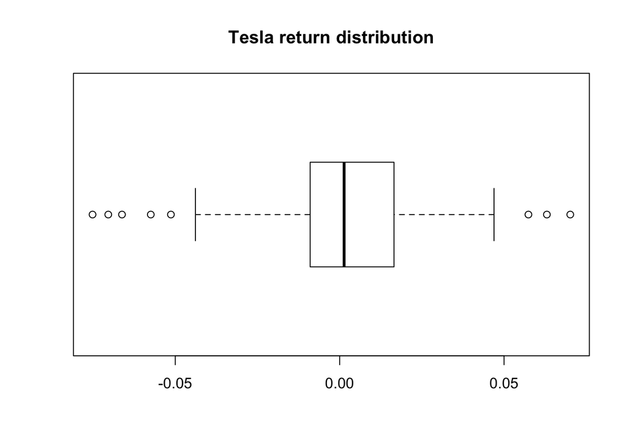

```r
rtn_box <- as.numeric(rtn)
boxplot(rtn_box,horizontal = TRUE,main=
          "Tesla return distribution")
```

###### The autocorrelation also is a powerful tool to assess the stock. It tells you whether there is a relation between the price of past and of present, even predicting the future.

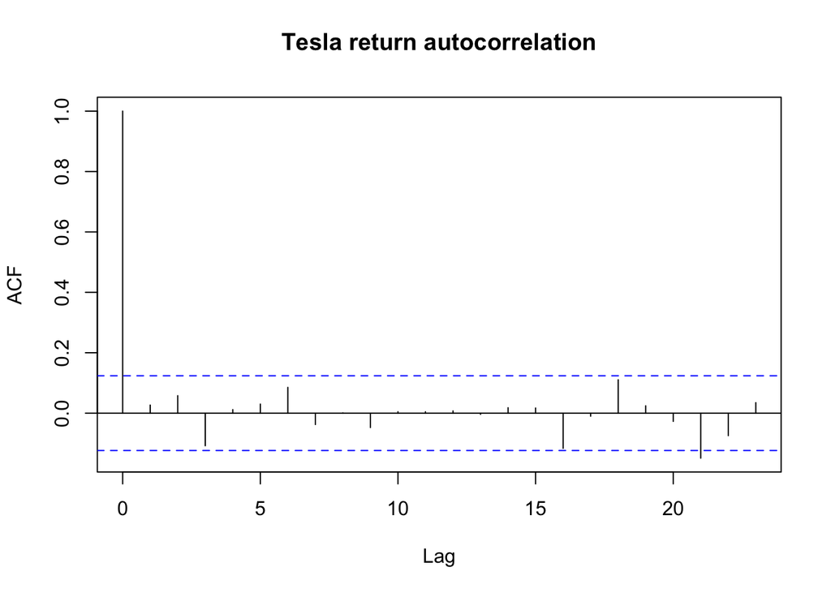

```r
acf(rtn,main="Tesla return autocorrelation")
```

```r
acf(rtn,plot = FALSE,lag.max = 1)
```

```
##
## Autocorrelations of series 'rtn', by lag
##
##     0     1
## 1.000 0.027
```

### Conclusion:

###### Wanna more fun? Adding the return of toyota which seems like a rival of Tesla motors, to the tesla stock.

```r
toyota <- read.csv("TOYOTA.csv")
rownames(toyota) <- toyota[,1]
toyota$Date <- NULL
toyota_stock <- xts(toyota,order.by = as.Date(rownames(toyota),"%m/%d/%Y"))
```

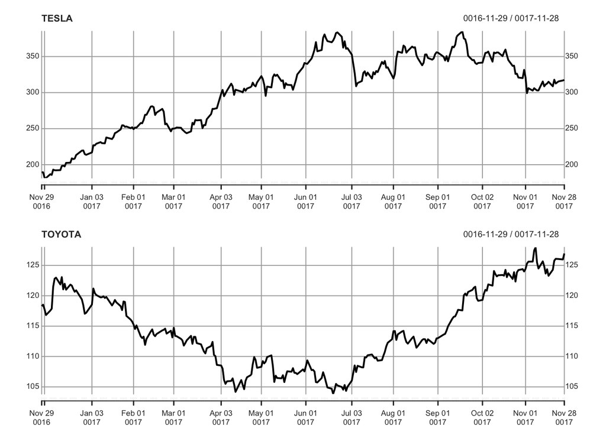

```r
par(mfrow=c(2,1))
plot(tesla_stock,main = "TESLA")
plot(toyota_stock,main="TOYOTA")
```

###### From the plot, I could see a interesting tread. When Tesla’s stock is racing，Toyota’s stock is decreaseing dramatically. Conversely, the time when Toyota;s stock is picking up, Tesla’s stock started to decline. How about

- the return plot?

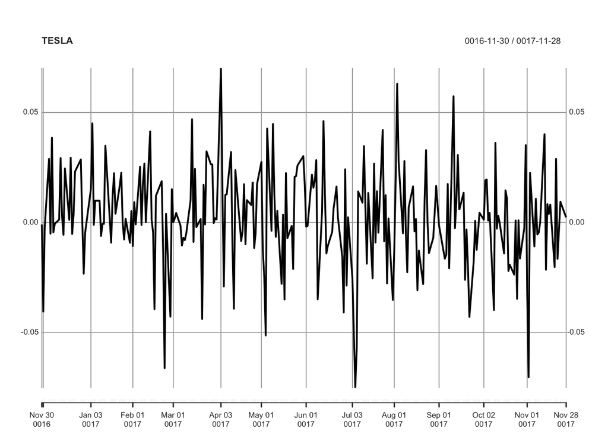

```r
rtn2 <- ROC(toyota_stock)

rtn2 <- rtn2[-1]
plot(rtn,main = "TESLA")
```

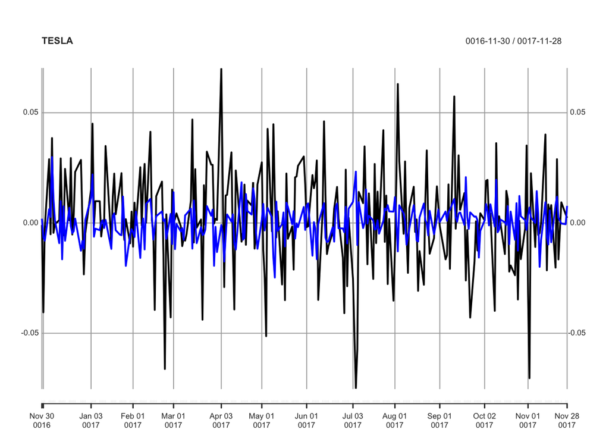

```r
lines(rtn2,col = "blue",lwd=2)
```

```r
acf(rtn2,plot=FALSE,lag.max = 1)
```

```
##
## Autocorrelations of series 'rtn2', by lag
##
##      0      1
##  1.000 -0.019
```

##### Taking home messages:

1. `You could go to Yahoo! finance to download any stock with any time frame you want.`
2. `Using simple yet powerful and useful plot function to observe the stock`
3. `How to use "xts","zoo" to convert data frame to the xts class.`
4. `Using par function to view several plots in one window.`
5. `Interpreting time series data by acf,box,and hitogram plots.`
6. `Last but not least, pick up a profitable and less risky stock!`

[figure not shown]

###### Reference:

- `https://support.minitab.com/en-us/minitab/18/help-and-how-to/modeling-statistics/time-series/how-to/autocorrelation/interpret-the-results/autocorrelation-function-acf/`
- `https://a-little-book-of-r-for-time-series.readthedocs.io/en/latest/src/timeseries.html#plotting-time-series`
- `https://finance.yahoo.com/screener`
- `http://www.stat.pitt.edu/stoffer/tsa4/R_toot.htm`
- `https://www.statmethods.net/advstats/timeseries.html`
- `https://www.scientificamerican.com/article/can-tesla-build-enough-electric-cars/`
- `https://petolau.github.io/Forecast-double-seasonal-time-series-with-multiple-linear-regression-in-R/`